# Bicycle Rentals exploration by Sreejith Gopinath

# Univariate plots section

These are the dimensions of the bicycle_rentals dataset

```
## [1] 17379    15
```

The features in this dataset are:

```
##  [1] "instant"    "dteday"     "season"     "yr"         "mnth"
##  [6] "hr"         "holiday"    "weekday"    "workingday" "weathersit"
## [11] "temp"       "atemp"      "hum"        "windspeed"  "cnt"
```

```
##   instant     dteday season yr mnth hr holiday  weekday workingday
## 1       1 2011-01-01 spring  0    1  0       0 Saturday          0
## 2       2 2011-01-01 spring  0    1  1       0 Saturday          0
## 3       3 2011-01-01 spring  0    1  2       0 Saturday          0
## 4       4 2011-01-01 spring  0    1  3       0 Saturday          0
## 5       5 2011-01-01 spring  0    1  4       0 Saturday          0
## 6       6 2011-01-01 spring  0    1  5       0 Saturday          0
##   weathersit temp  atemp  hum windspeed cnt      DoW
## 1      clear 0.24 0.2879 0.81    0.0000  16 Saturday
## 2      clear 0.22 0.2727 0.80    0.0000  40 Saturday
## 3      clear 0.22 0.2727 0.80    0.0000  32 Saturday
## 4      clear 0.24 0.2879 0.75    0.0000  13 Saturday
## 5      clear 0.24 0.2879 0.75    0.0000   1 Saturday
## 6       mild 0.24 0.2576 0.75    0.0896   1 Saturday
```

```
## [1] "clear"        "mild"         "light precip" "heavy precip"
```

```
## [1] "spring" "summer" "fall"   "winter"
```

```
## 'data.frame':    17379 obs. of  16 variables:
##  $ instant   : int  1 2 3 4 5 6 7 8 9 10 ...
##  $ dteday    : Factor w/ 731 levels "2011-01-01","2011-01-02",..: 1 1 1 1 1 1 1 1 1 1 ...
##  $ season    : chr  "spring" "spring" "spring" "spring" ...
##  $ yr        : int  0 0 0 0 0 0 0 0 0 0 ...
##  $ mnth      : int  1 1 1 1 1 1 1 1 1 1 ...
##  $ hr        : int  0 1 2 3 4 5 6 7 8 9 ...
##  $ holiday   : int  0 0 0 0 0 0 0 0 0 0 ...
##  $ weekday   : chr  "Saturday" "Saturday" "Saturday" "Saturday" ...
##  $ workingday: int  0 0 0 0 0 0 0 0 0 0 ...
##  $ weathersit: chr  "clear" "clear" "clear" "clear" ...
##  $ temp      : num  0.24 0.22 0.22 0.24 0.24 0.24 0.22 0.2 0.24 0.32 ...
##  $ atemp     : num  0.288 0.273 0.273 0.288 0.288 ...
##  $ hum       : num  0.81 0.8 0.8 0.75 0.75 0.75 0.8 0.86 0.75 0.76 ...
##  $ windspeed : num  0 0 0 0 0 0.0896 0 0 0 0 ...
##  $ cnt       : int  16 40 32 13 1 1 2 3 8 14 ...
##  $ DoW       : Factor w/ 7 levels "Sunday","Monday",..: 7 7 7 7 7 7 7 7 7 7 ...
```

```
##     instant             dteday         season                yr
##  Min.   :    1   2011-01-01:   24   Length:17379       Min.   :0.0000
##  1st Qu.: 4346   2011-01-08:   24   Class :character   1st Qu.:0.0000
##  Median : 8690   2011-01-09:   24   Mode  :character   Median :1.0000
##  Mean   : 8690   2011-01-10:   24                      Mean   :0.5026
##  3rd Qu.:13034   2011-01-13:   24                      3rd Qu.:1.0000
##  Max.   :17379   2011-01-15:   24                      Max.   :1.0000
##                  (Other)   :17235
##       mnth              hr           holiday          weekday
##  Min.   : 1.000   Min.   : 0.00   Min.   :0.00000   Length:17379
##  1st Qu.: 4.000   1st Qu.: 6.00   1st Qu.:0.00000   Class :character
##  Median : 7.000   Median :12.00   Median :0.00000   Mode  :character
##  Mean   : 6.538   Mean   :11.55   Mean   :0.02877
##  3rd Qu.:10.000   3rd Qu.:18.00   3rd Qu.:0.00000
##  Max.   :12.000   Max.   :23.00   Max.   :1.00000
##
##    workingday      weathersit             temp           atemp
##  Min.   :0.0000   Length:17379       Min.   :0.020   Min.   :0.0000
##  1st Qu.:0.0000   Class :character   1st Qu.:0.340   1st Qu.:0.3333
##  Median :1.0000   Mode  :character   Median :0.500   Median :0.4848
##  Mean   :0.6827                      Mean   :0.497   Mean   :0.4758
##  3rd Qu.:1.0000                      3rd Qu.:0.660   3rd Qu.:0.6212
##  Max.   :1.0000                      Max.   :1.000   Max.   :1.0000
##
##       hum           windspeed           cnt               DoW
##  Min.   :0.0000   Min.   :0.0000   Min.   :  1.0   Sunday   :2502
##  1st Qu.:0.4800   1st Qu.:0.1045   1st Qu.: 40.0   Monday   :2479
##  Median :0.6300   Median :0.1940   Median :142.0   Tuesday  :2453
##  Mean   :0.6272   Mean   :0.1901   Mean   :189.5   Wednesday:2475
##  3rd Qu.:0.7800   3rd Qu.:0.2537   3rd Qu.:281.0   Thursday :2471
##  Max.   :1.0000   Max.   :0.8507   Max.   :977.0   Friday   :2487
##                                                    Saturday :2512
```

Here is a complete list of features in the dataset, along with their meanings:

[output not shown]

## *Sounds interesting!!*

```
##         dteday cnt
## 668 2012-10-29  22
## 27  2011-01-27 431
## 726 2012-12-26 441
## 26  2011-01-26 506
## 65  2011-03-06 605
## 69  2011-03-10 623
```

We see from the preceding dataframe dump that the lowest ever bicycle rentals in our dataset happened on 29th October 2012. A simple web search shows us that this was the day Hurricane Sandy made landfall in the Washington DC area - a majority of schools, colleges and offices had shut down! The next low occurred on 27th January 2011. On this day, it was a blizzard that had shut down Washington DC! Thus, analyzing transportation statistics over a period of time and co-relating incidents that correspond to variations to the trend, may help us build predictive models.

Let us look at some plots now.

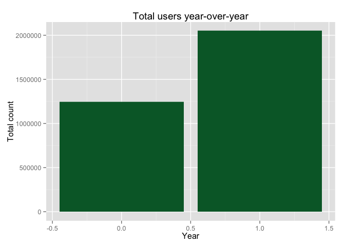

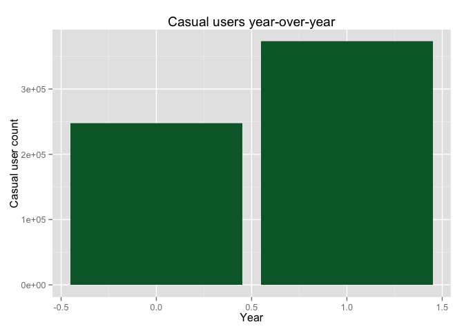

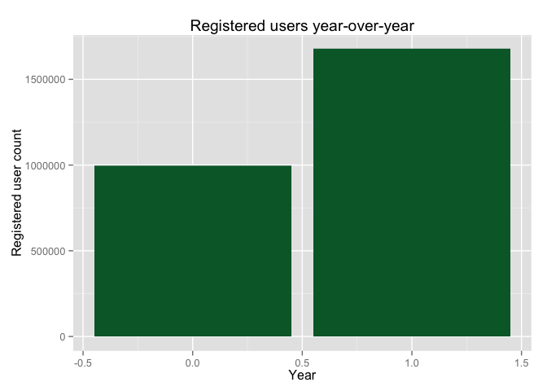

The first plot on the left shows the total number of users renting bicycles in each of the two years for which we have data. At a very high level, we see that the total number of users in the initial year are outnumbered by the total number of users in the subsequent year. I attribute this trend to a number of possible factors like rise in popularity of the rental service, increase in the travelling population and increase in the crowding factor on other modes of public transportation.  
The second plot shows the total number of casual users renting bicycles in the two years for which we have data. We see that the total number of casual users in the initial year are outnumbered by the total number of users in the subsequent year.  
The last plot shows the total number of registered users renting bicycles in the two years for which we have data. We see that the total number of registered users in the initial year are outnumbered by the total number of users in the subsequent year. We also see that the year-over-year increase in registered users is greater than the year-over-year increase in casual users. This may be due to casual-to-registered user conversion, or simply more people choosing to register than rent casually.  
I chose to include these plot because I wanted to look at the overall trends and whether there were any opposing trends among casual and registered users. We do not see any opposing trends, but it looks like registered ridership is signaling the popularity of the service.

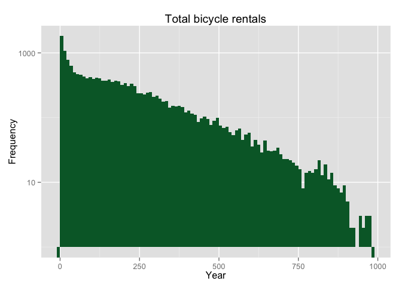

The bicycle rental frequencies seem to progressively decline for higher counts. I chose to include this plot because I wanted to convey a sense of popularity for the service. We see that daily/hourly instances with lower total bicycle rentals happen more frequently than daily/hourly instances with higher total rentals.  
I wonder how the frequencies will vary by season and weather conditions.

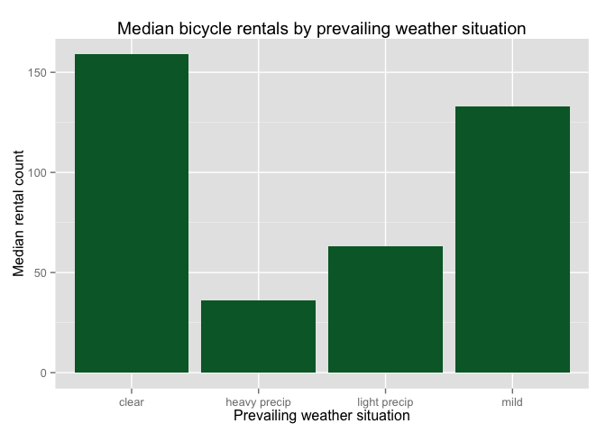

As is intuitive, we see that bicycle rentals are highest when the weather is clear, next highest when the weather is just misty, a few brave souls renting bicycles when there is light precipitation and least when there is heavy precipitation. I chose to include this plot because bicycle transportation is open to the elements and is therefore very different from other modes of transportation. I wanted to get an initial sense of whether the prevailing conditions played a major role in influencing bicycle rentals.

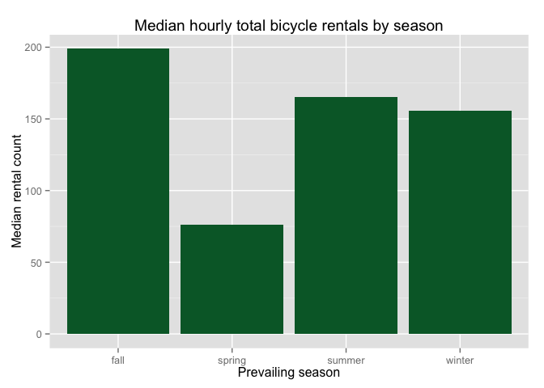

I cannot fathom the reason for this, but it looks like bicycle rentals are highest in the fall, next highest in summer, third in winter and lowest in spring. As in the previous plot, I wanted to explore whether prevailing conditions played a part in influencing bicycle rentals. Looking at the seasonal trends, we get a fair sense of how general cold weather/warm weather, etc. influence bicycle rentals.

Next, I subset-ed the data into two groups - one subset for holidays and one subset for working days. Here are the summaries of the bicycle rental numbers for the respective subsets:

```
##    Min. 1st Qu.  Median    Mean 3rd Qu.    Max.
##     1.0    40.0   144.0   190.4   281.5   977.0
```

```
##    Min. 1st Qu.  Median    Mean 3rd Qu.    Max.
##    1.00   28.75   97.00  156.90  253.20  712.00
```

From the preceding stats, we see that, all else set aside, bicycle rental numbers are higher on working days than on holidays - indicating that bicycle rentals may not be for recreational use.

Next, let’s explore how bicycle rentals stack up by day of the week.

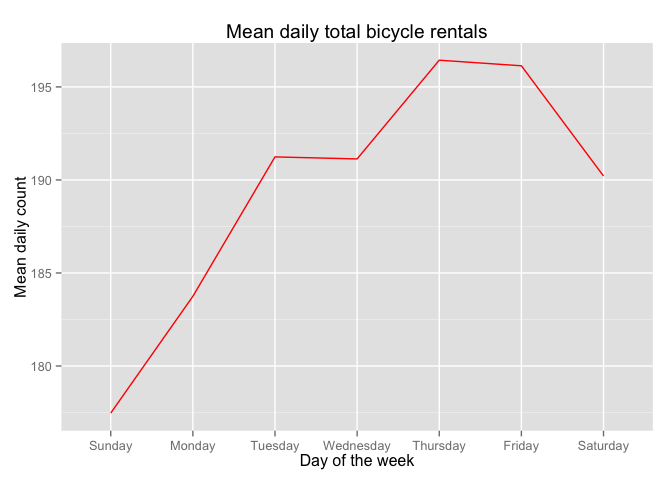

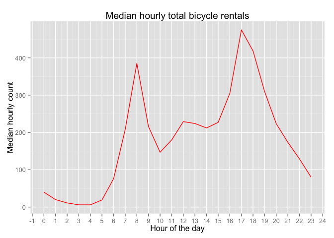

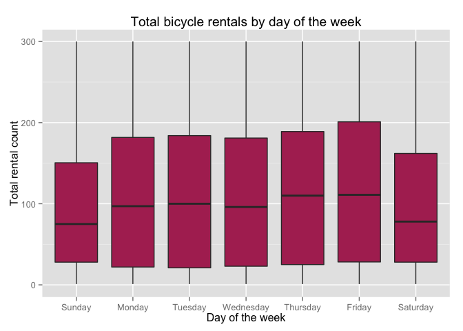

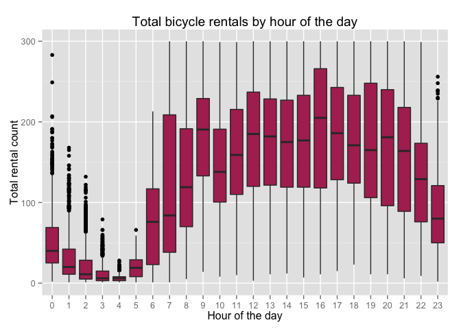

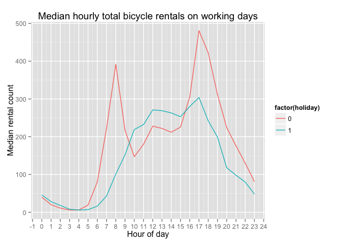

The preceding plot shows the median total bicycle rentals on working days for each hour of the day(line in red). On working days, the trend is pretty close to the trends overall, suggesting that bicycle rentals are primarily driven by office/school-goers. This plot continues the exploration from where we left off in the previous plot. The line in blue shows bicycle rentals by the hour on holidays. The plot for holidays shows higher numbers during the middle portion of the day. I chose these plots because I wanted to see if the hourly trends on working days matched the hourly trends on all days. It does follow closely, reinforcing our belief that bicycle rentals are primarily used by commuters.

Let us now see how the numbers of casual and registered renters vary by the day of the week and the hour of the day.

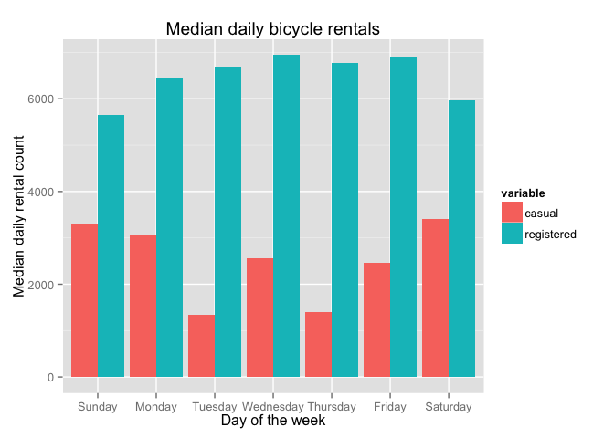

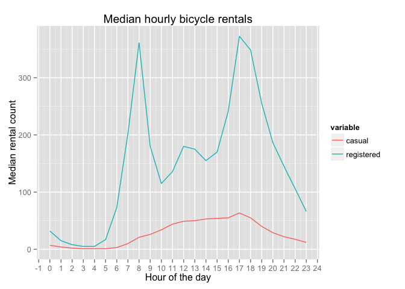

From plot on the left, we see that casual ridership is higher on weekends than on weekdays, while the trend is reversed for registered ridership. We also see that the hourly ridership plot for registered riders is similar to the overall hourly ridership plot - which means that rental registration is a pretty good predictor of bicycle rentals.  
Though this plot may have better belonged in the bivariate section, I chose to include this plot here because it nicely wraps up the conclusions drawn in the preceding graphs. We see how registered users(more likely commuter than not) drive up rentals in the middle portion of the week while casual(more likely to be recreational users than not) drive up rentals during the weekend.

# Univariate analysis

*What is the structure of your dataset?*  
I am working with the bicycle rentals dataset, which contains bicycle rentals information at an agency in Washington DC., for the years 2011-2012. The dataset also contains weather data for the same days as the bicycle rentals.  
The dataset contains 731 daily records as well as 17379 hourly records for bicycle rentals at one agency in the city.  
There are 17 features in the hourly dataset, and they are listed here:  
**instant** - An index for the record  
**dteday** - The date  
**season** - The prevailing climatic season  
**yr** - Year  
**mnth** - Month  
**hr** - The hour of observation  
**holiday** - Whether or not the particular day was a holiday(weekends are counted as holidays too)  
**weekday** - The day of the week  
**workingday** - Whether or not the particular day was a working day(inverse of the holiday value)  
**weathersit** - What kind of weather prevailed on the particular day  
**temp** - The hourly temperature  
**atemp** - The average temperage for the day  
**hum** - The humidity on the particular day  
**windspeed** - The windspeed on the particular day  
**casual** - The number of rentals by non-registered customers  
**registered** - The number of rentals by registered customers  
**cnt** - Total number of rentals

The variables *weathersit*, *season*, *holiday* and *workingday* are categorical variables.  
**weathersit** has four states that I have simplified into: *clear*, *misty*, *light_precipi*(light rain/snow) and *heavy_precipi*(heavy rain/sleet/ snow).  
**season** has four states: *spring*, *summer*, *fall* and *winter*.  
**holiday** and **workingday** are categorical variables that have binary values and orthogonal with each other in each observation.  
Other observations:  
1) Most bicycle rentals are made by registered customers than casual customers.  
2) More bicycle rentals are made by people that are commuting to their jobs/schools than recreational customers.  
3)Bicycle rentals are higher in dry weather than wet weather.

*What is/are the main feature(s) of interest in your dataset?*  
The main feature of interest in the dataset is the bicycle rental count. I am trying to build a prediction model for bicycle rentals. From our univariate analyses, we have seen that the general weather situation and season have pretty good predictive power.

*What other features in the dataset do you think will help support your investigation into your feature(s) of interest?*  
We need to analyse some more to build a prediction model with higher confidence.  
I suspect windspeed, humidity and temperature will play a role in predicting bicycle rentals, but we shall see.

# Bivariate plots section

From the univariate analyses performed so far, I have seen that some features tend to correlate with each other. For example, average temperatures and precipitation seem to correlate with the season in a broader sense; these variables also seem to correlate with the weather situation in a much more specific sense.

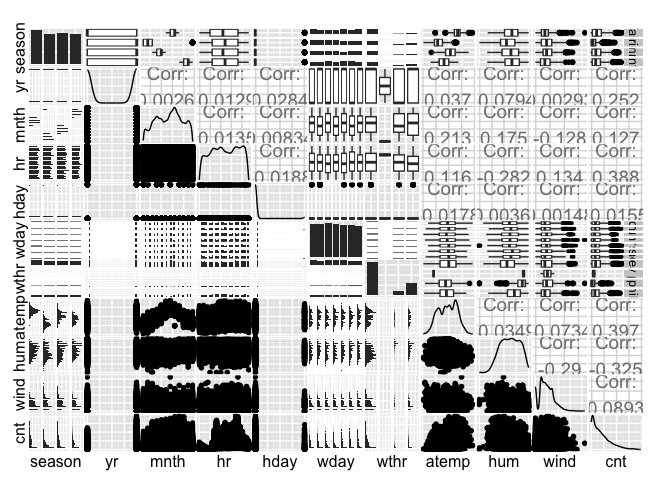

A quick look at the correlation data shows that bicycle rentals are mostly influenced by the feeling temperature and hour of the day. I chose to include the correlation chart because it shows correlation scores for different pairs of features and therefore will give us a good idea of what relationships we should be exploring in detail.

I will now explore some scatter plots involving total bicyle rentals together with normalized daily feeling temperatures, humidity and windspeed.

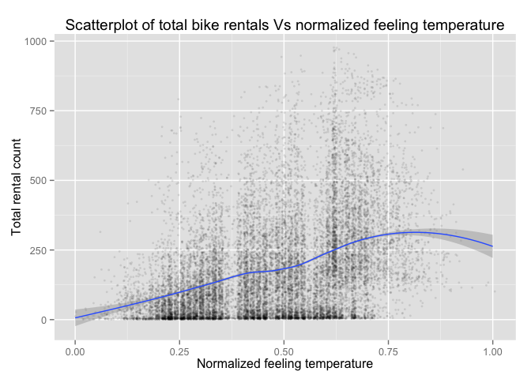

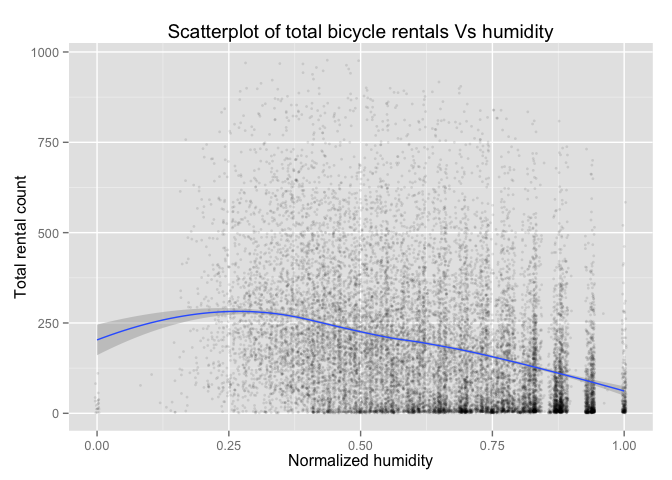

From the preceding plots, we see that most bicycle rentals occur when the normalized humidity is between 0.30-0.80.Taking a closer look at the rental number distributions between normalized humidities of 0.75-1.0, we see that there are certain “pockets” of distributions. At this point, it is not entirely clear what might be causing these distributions. It may be because certain values of normalized humidity never occur. From the correlation chart above, we see that there is a negative correlation between the total bicycle rental numbers and the prevailing humidity, with a correlation score of -0.325. I chose to include this plot because it helps us reinforce in greater details the relationship between the total number of bicycle rentals and the prevailing humidity that was revealed by the correlation chart.

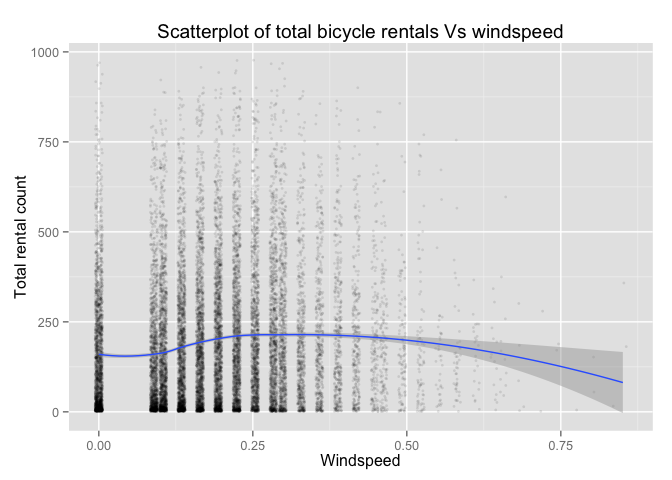

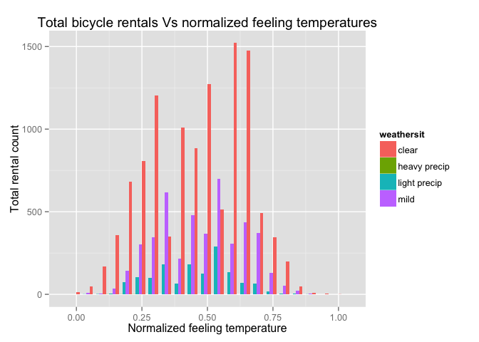

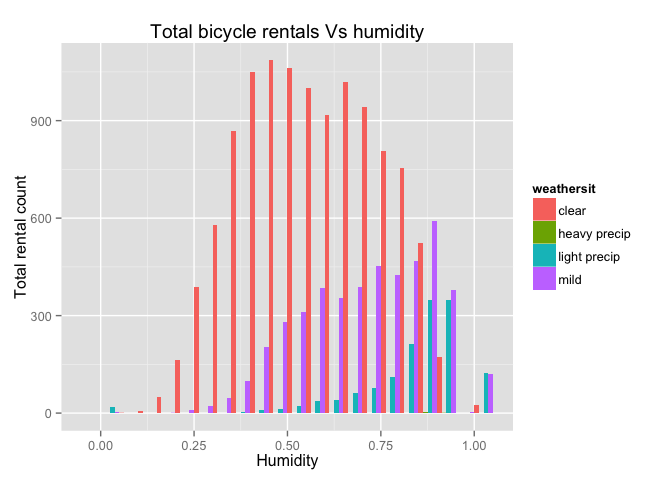

From the preceding plot, we see that most of the humidity range is dominated by clear weather and this is where a bulk of bicycle rentals take place. We do see a few peaks towards the higher end of the humidity spectrum, and this quartile seems to be dominated by misty weather for the most part and precipitative weather to a lesser extent.  
Since the weather factors tend to straddle seasons and even occur unseasonally, I included this chart to explore how bicycle rentals vary with the prevailing humidity. Overlaying it with the prevailing weather situation shows us the the different weather situations in which the humidity values occur.

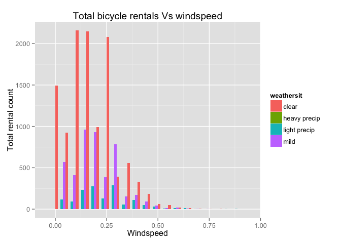

```
##              Min. 1st Qu. Median   Mean 3rd Qu. Max.
## clear           1    46.0    159 204.90   304.0  977
## heavy precip   23    29.5     36  74.33   100.0  164
## light precip    1    21.0     63 111.60   152.5  891
## mild            1    40.0    133 175.20   257.0  957
```

Let’s also look at a summary of bicycle rentals by season.

```
##        Min. 1st Qu. Median  Mean 3rd Qu. Max.
## fall      1      68  199.0 236.0     345  977
## spring    1      23   76.0 111.1     158  801
## summer    1      46  165.0 208.3     311  957
## winter    1      46  155.5 198.9     295  967
```

From the above summary, it looks like bicycle rentals are high in the fall and summer and taper off in the winter and spring.  
Let’s now look at the number of casual bicycle rentals per season.

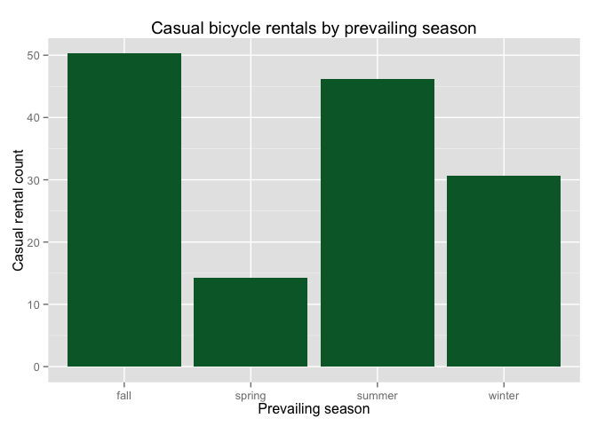

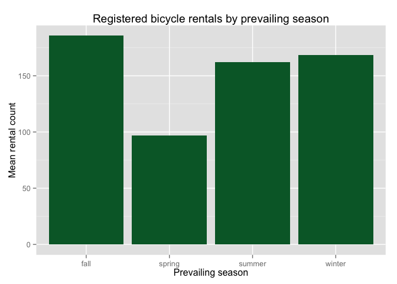

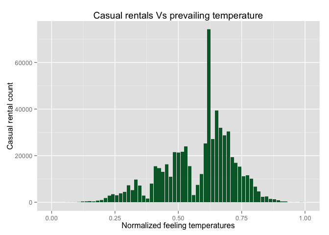

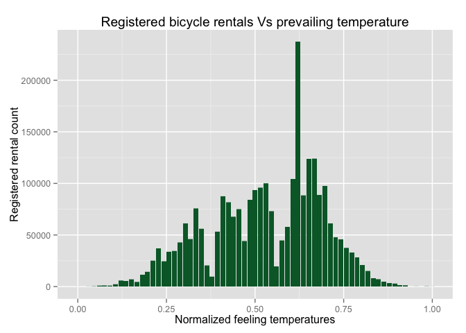

In the plot on the left, we see how casual bicycle rentals stack up against the prevailing temperature. The highest number of casual bicycle rentals happen between normalized temperatures of 0.55 and 0.75.  
In the plot on the right, we see how registered bicycle rentals stack up against the prevailing temperatures. As in the case of casual riders, normalized temperatures 0.48 to 0.75 seem to be most popular.  
I chose to include these plots because it is interesting to see how the distribution of casual and registered bicycle rentals each vary by the prevailing temperatures. It also helps us appreciate that the relationship between bicycle rental numbers and prevailing temperatures is non-linear and why temperature may not have too much of an influence on a linear model built to predict casual bicycle rentals.

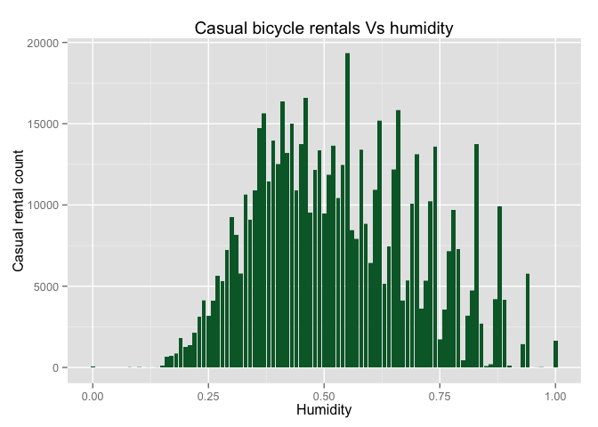

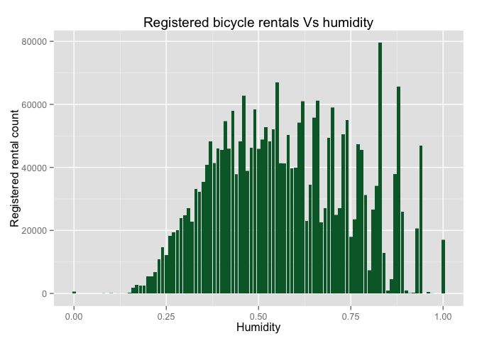

In the plot on the left, we see how casual bicycle rentals stack up against the prevailing humidity. We see that normalized humidity ranges between 0.30 and 0.55 seem to be very popular among casual bicycle rentals.  
In the plot on the right, we explore how registered bicycle rentals stack up against the prevailing humidity. For registered users, we see that normalized humidity values between 0.30 and 0.75 are most popular among registered riders.  
I chose to include these plots because it helps us appreciate that the relationship between bicycle rental numbers and the prevailing humidity is non-linear and why the humidity factor is likely to not have a great influence on any linear model we build to predict bicycle rentals.

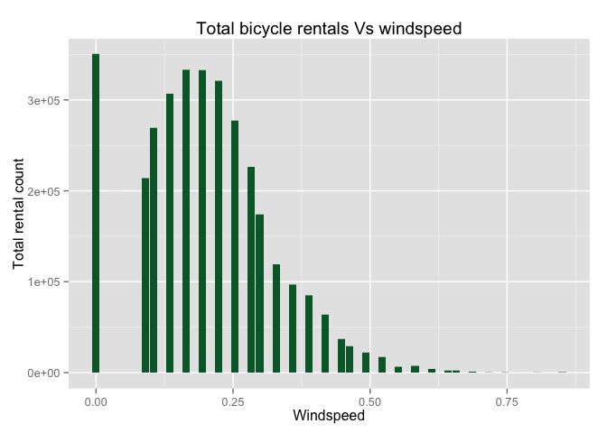

In the preceding plot, we see how total bicycle rentals stack up against the prevailing wind conditions. We see that bicycle rentals are highest when the windspeed is low, dropping off as the prevailing windspeed picks up.  
The correlation between bicycle rentals and windspeed is very low, as evidenced by the correlation chart we saw earlier. However, I chose to include this plot because it shows the distribution of bicycle rental numbers across the spectrum of windspeed and helps us appreciate the fact that there is no linear relationship between the two.

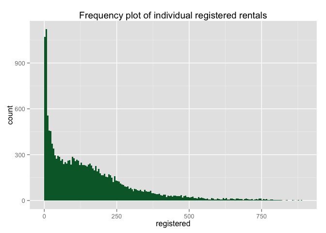

The preceding plot is a frequency plot of bicycle rentals. Most rentals happen in small numbers at a time, which shows that the popularity of the service is still picking up. As popularity increases, we should expect to see more occurences of higher number of bikes per day.

Though the number of registered riders using the service is consistently higher than the number of casual renters, we see that the general trends remain the same. Registered users seem to be a little more loyal than casual users, in that the winter ridership is about the same as the summer ridership - whereas it is much lower in the case of casual users.  
I chose to include this plot in the report because this chart shows what we may call the “popularity score” for the bicycle rental service as a whole.

We have already seen that average feeling temperatures and hour of the day are the main influencers of bicycle rentals. Let’s look at how different weather conditions vary with the categorical variables.  
We already have a feel for how feeling temperatures are connected with weather conditions. We will see how average feeling temperatures vary by season.

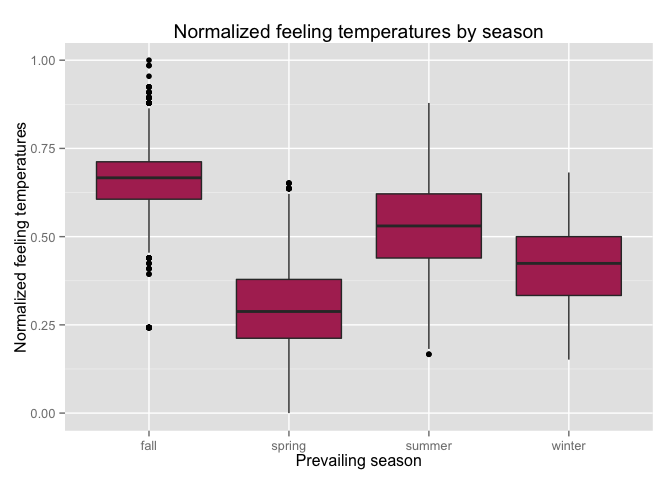

```
##          Min. 1st Qu. Median   Mean 3rd Qu.   Max.
## fall   0.2424  0.6061 0.6667 0.6560  0.7121 1.0000
## spring 0.0000  0.2121 0.2879 0.2981  0.3788 0.6515
## summer 0.1667  0.4394 0.5303 0.5205  0.6212 0.8788
## winter 0.1515  0.3333 0.4242 0.4157  0.5000 0.6818
```

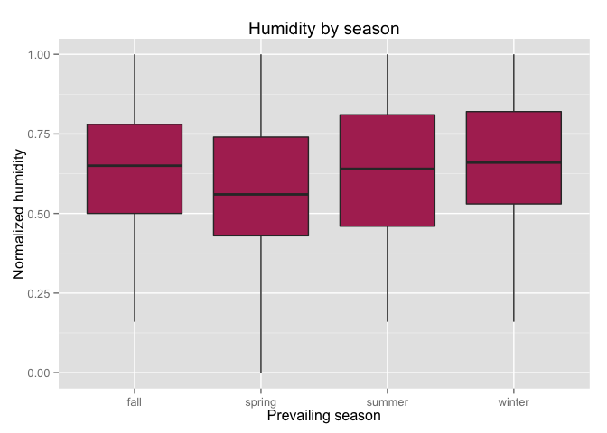

```
##        Min. 1st Qu. Median   Mean 3rd Qu. Max.
## fall   0.16    0.50   0.65 0.6332    0.78    1
## spring 0.00    0.43   0.56 0.5813    0.74    1
## summer 0.16    0.46   0.64 0.6270    0.81    1
## winter 0.16    0.53   0.66 0.6671    0.82    1
```

Humidity values are highest in winter, about the same in fall and summer, and lowest in spring. This is contrary to the trends we see for bicycle rentals. This reinforces our finding that humidity is not a great predictor of bicycle rentals. I chose to include this plot because I wanted to explore the relationship between the humidity and season features. I chose a boxplot because it lets us see the seasonal medians as well as any noisy data points.  
Let us take a look at how windspeeds influence bicycle rentals.

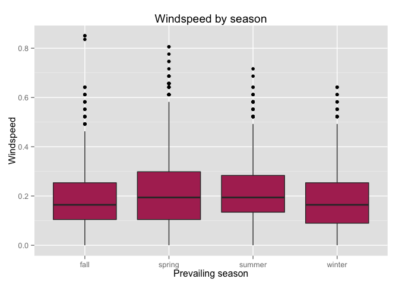

```
##        Min. 1st Qu. Median   Mean 3rd Qu.   Max.
## fall      0  0.1045 0.1642 0.1716  0.2537 0.8507
## spring    0  0.1045 0.1940 0.2151  0.2985 0.8060
## summer    0  0.1343 0.1940 0.2034  0.2836 0.7164
## winter    0  0.0896 0.1642 0.1708  0.2537 0.6418
```

Windspeeds are highest in spring and summer, and about the same in fall and winter. This trend is contrary to the bicycle rental trends .  
From the preceding boxplots, we see that only average feeling temperature trends mimic that of bicycle rentals. The choice of the preceding boxplots was driven by my desire to explore the relationship between features and how they strengthen or weaken each other. I used boxplots because while a particular range of values of a given feature is dominant for the season, unseasonal values do occur; I wanted to quantify how frequent these unseasonal values would be.

```
##
## Call:
## lm(formula = cnt ~ registered, data = df_master)
##
## Residuals:
##      Min       1Q   Median       3Q      Max
## -118.031  -16.264   -9.957    4.730  304.223
##
## Coefficients:
##              Estimate Std. Error t value Pr(>|t|)
## (Intercept) 10.296458   0.459718    22.4   <2e-16 ***
## registered   1.165032   0.002131   546.8   <2e-16 ***
## ---
## Signif. codes:  0 '***' 0.001 '**' 0.01 '*' 0.05 '.' 0.1 ' ' 1
##
## Residual standard error: 42.51 on 17377 degrees of freedom
## Multiple R-squared:  0.9451, Adjusted R-squared:  0.9451
## F-statistic: 2.99e+05 on 1 and 17377 DF,  p-value: < 2.2e-16
```

The linear model above shows how the registered user count influences the total count. We see that the correlation is pretty high, with an r^2 value of 0.945.

```
##
## Call:
## lm(formula = cnt ~ temp, data = df_master)
##
## Residuals:
##     Min      1Q  Median      3Q     Max
## -291.37 -110.23  -32.86   76.77  744.76
##
## Coefficients:
##             Estimate Std. Error t value Pr(>|t|)
## (Intercept)  -0.0356     3.4827   -0.01    0.992
## temp        381.2949     6.5344   58.35   <2e-16 ***
## ---
## Signif. codes:  0 '***' 0.001 '**' 0.01 '*' 0.05 '.' 0.1 ' ' 1
##
## Residual standard error: 165.9 on 17377 degrees of freedom
## Multiple R-squared:  0.1638, Adjusted R-squared:  0.1638
## F-statistic:  3405 on 1 and 17377 DF,  p-value: < 2.2e-16
```

The linear model above shows how the prevailing temperatures influence the total bicycle rental count. There is a moderate correlation, with an r^2 value of 0.1638.

```
##
## Call:
## lm(formula = cnt ~ hr, data = df_master)
##
## Residuals:
##     Min      1Q  Median      3Q     Max
## -305.86 -102.80  -45.85   66.50  730.16
##
## Coefficients:
##             Estimate Std. Error t value Pr(>|t|)
## (Intercept)  70.0952     2.4616   28.48   <2e-16 ***
## hr           10.3378     0.1829   56.52   <2e-16 ***
## ---
## Signif. codes:  0 '***' 0.001 '**' 0.01 '*' 0.05 '.' 0.1 ' ' 1
##
## Residual standard error: 166.7 on 17377 degrees of freedom
## Multiple R-squared:  0.1553, Adjusted R-squared:  0.1552
## F-statistic:  3195 on 1 and 17377 DF,  p-value: < 2.2e-16
```

The linear model above shows how the total bicycle rentals are influenced by the hour of the day. We see that there is a moderate correlation, with an r^2 value of 0.1552.

```
##
## Call:
## lm(formula = cnt ~ season, data = df_master)
##
## Residuals:
##     Min      1Q  Median      3Q     Max
## -235.02 -118.87  -39.11   85.89  768.13
##
## Coefficients:
##              Estimate Std. Error t value Pr(>|t|)
## (Intercept)   236.016      2.615  90.268  < 2e-16 ***
## seasonspring -124.902      3.753 -33.284  < 2e-16 ***
## seasonsummer  -27.672      3.716  -7.447 9.99e-14 ***
## seasonwinter  -37.147      3.755  -9.893  < 2e-16 ***
## ---
## Signif. codes:  0 '***' 0.001 '**' 0.01 '*' 0.05 '.' 0.1 ' ' 1
##
## Residual standard error: 175.3 on 17375 degrees of freedom
## Multiple R-squared:  0.06599,    Adjusted R-squared:  0.06583
## F-statistic: 409.2 on 3 and 17375 DF,  p-value: < 2.2e-16
```

The linear model above shows how the total bicycle rentals are influenced by the prevailing season. We see that there is a slight correlation, with an r^2 value of 0.06583.  
I chose to include the linear models above because, in anticipation of building a linear prediction model, I am trying to decide on a set of features. From the correlation chart and other plots above, we already have a fair idea of what features may have a strong correlation with the bicycle rental numbers; the linear models above help us to quantify that influence.